# Entrega práctica 4 Modelización de variables dasométricas

Monica Carriere Cañada

2023-05-05

## Objetivo

El objetivo de esta práctica es crear modelos que relacionen variables dasométricas con variables LiDAR obtenidas con LASTools o en campo en el caso de las variables dasométricas. En nuestro caso, la unión de los datos LiDAR y los datos de campo para las distintas parcelas se hizo ya en Excel mediante Power Query (Combinar tablas) con el campo ‘Name’ como campo común.

Lo primero es cargar las librerías necesarias y los datos para implementar los modelos.

```r
rm(list=ls())

pck <- (c("tidyr", "dplyr", "readxl", "ggplot2", "randomForest", "car", "Metrics", "caret", "pls","car"))

sapply(pck, require, character.only=TRUE)
```

```
##        tidyr        dplyr       readxl      ggplot2 randomForest          car
##         TRUE         TRUE         TRUE         TRUE         TRUE         TRUE
##      Metrics        caret          pls          car
##         TRUE         TRUE         TRUE         TRUE
```

```r
data <- read.csv("E:/GEOFOREST/LiDARII/Practicas/Practicas_1-5/Practica4/BBDD.csv", sep=";")
```

## Análisis exploratorio

Ahora pasamos a explorar distintas relaciones existentes entre variables dasométricas y variables LiDAR. Por ejemplo, podemos intuir las siguientes relaciones:

- La altura dominante estará relacionada con los percentiles altos especialmente (p90-p95), con los valores máximo y mínimo de altura (especialmente máximo, quizás con el mínimo de forma inversa)
- La altura media estará relacionada con el percentil 50, y con la métrica de altura media (avg)
- El número de pies por hectárea estará relacionado con la métrica de densidad o cobertura, al igual que el área basimétrica.
- El área basimétrica estará relacionada con la métrica de densidad (número de todos los retornos entre el número total de todos los retornos) o cobertura (número de primero retornos entre el número total de primeros retornos en %) de LASTools.

Exploramos de forma preliminar la relación entre cada variable dasométrica y todas las métricas LiDAR por grupos de métricas (alturas, precentiles, bicentiles, métricas de forma, etc), para confirmar o no estas relaciones lógicas.

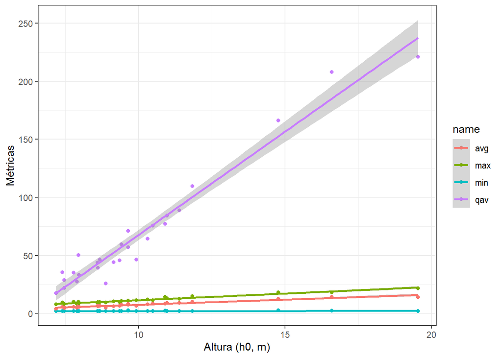

```r
# Ejemplo
h0_1 <-data %>% dplyr::select(13:16, H0_m)
h0_1 <- h0_1 %>%  pivot_longer(cols = -H0_m)
h0_1 <- h0_1 %>% filter(value > 0.5)

h0_1 %>% ggplot(aes(x = H0_m, y = value, color = name)) + geom_point()+
  stat_smooth(method="lm", formula=y ~ x) +theme_bw()+
  ylab("Métricas")+ xlab("Altura (h0, m)")
```

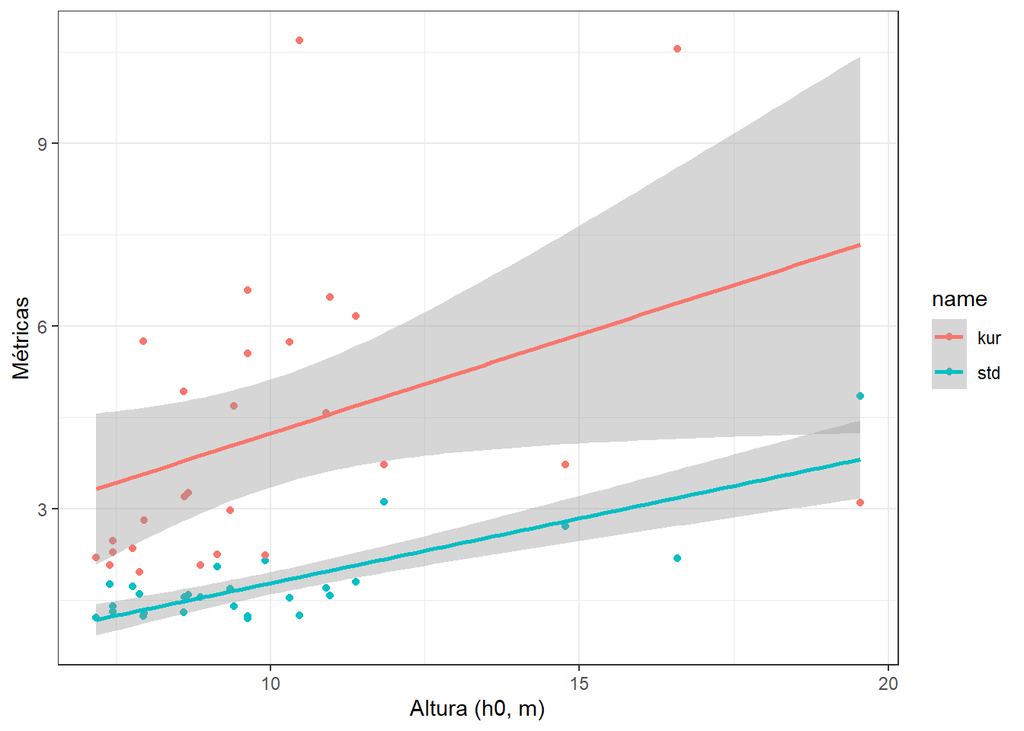

```r
h0_2 <-data %>% dplyr::select(17:19, H0_m)
h0_2 <- h0_2 %>%  pivot_longer(cols = -H0_m)
h0_2 <- h0_2 %>% filter(value > 0.5)

h0_2 %>% ggplot(aes(x = H0_m, y = value, color = name)) + geom_point()+
  stat_smooth(method="lm", formula=y ~ x) +theme_bw()+
  ylab("Métricas")+ xlab("Altura (h0, m)")
```

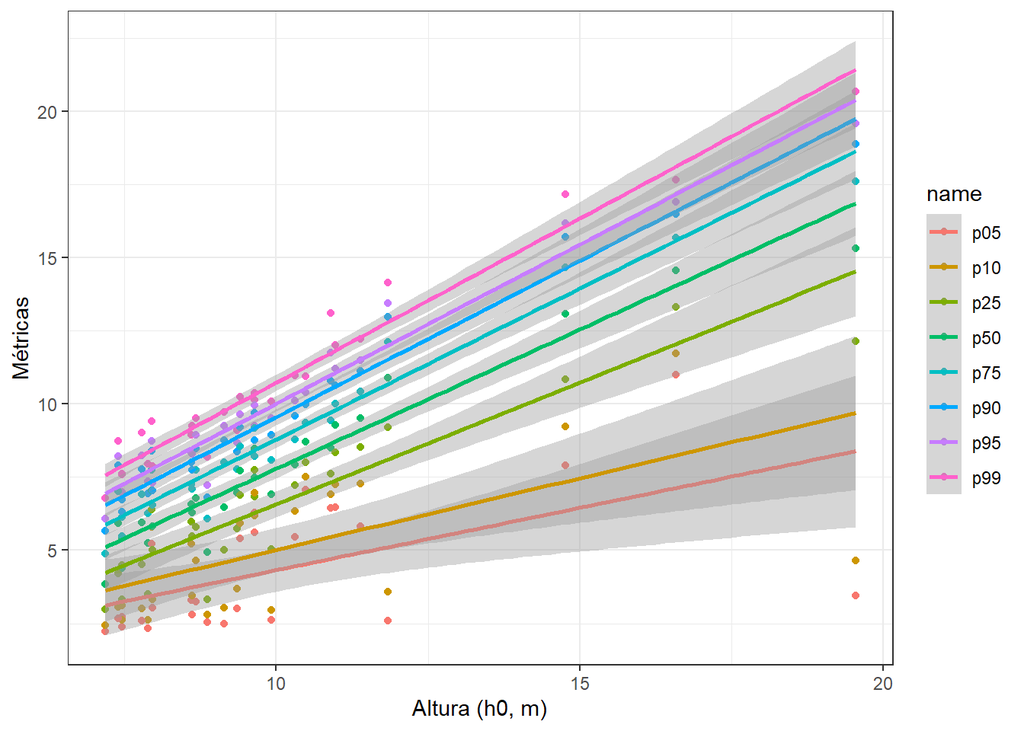

```r
h0_3 <-data %>% dplyr::select(20:27, H0_m)
h0_3 <- h0_3 %>%  pivot_longer(cols = -H0_m)
h0_3 <- h0_3 %>% filter(value > 0.5)

h0_3 %>% ggplot(aes(x = H0_m, y = value, color = name)) + geom_point()+
  stat_smooth(method="lm", formula=y ~ x) +theme_bw()+
  ylab("Métricas")+ xlab("Altura (h0, m)")
```

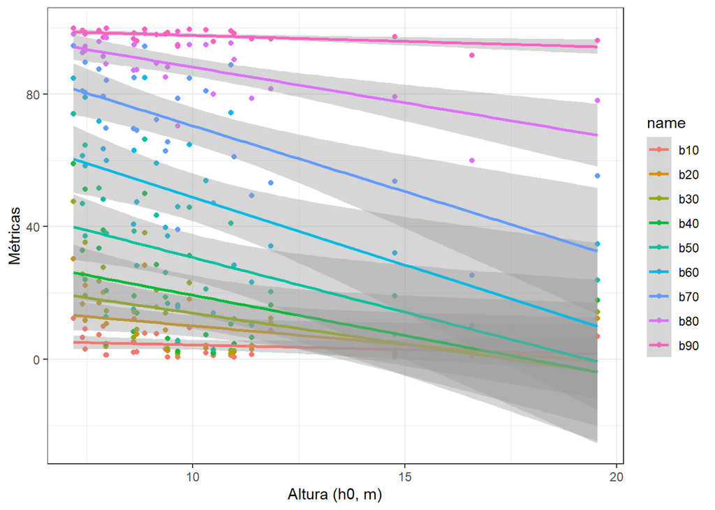

```r
h0_4 <-data %>% dplyr::select(28:36, H0_m)
h0_4 <- h0_4 %>%  pivot_longer(cols = -H0_m)
h0_4 <- h0_4 %>% filter(value > 0.5)

h0_4 %>% ggplot(aes(x = H0_m, y = value, color = name)) + geom_point()+
  stat_smooth(method="lm", formula=y ~ x) +theme_bw()+
  ylab("Métricas")+ xlab("Altura (h0, m)")
```

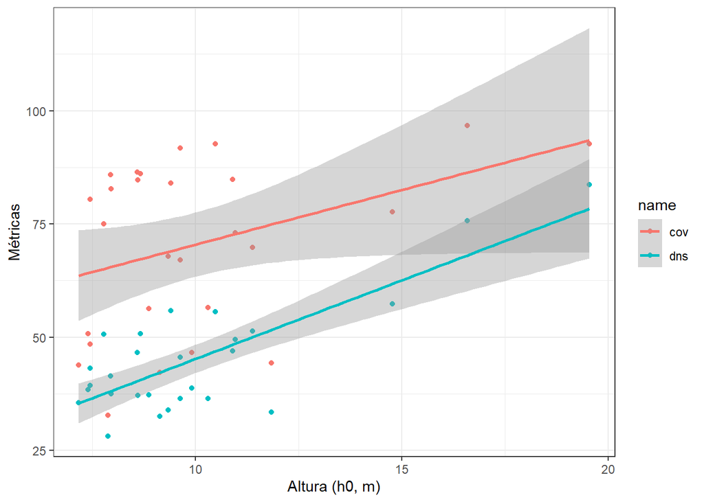

```r
h0_5 <-data %>% dplyr::select(37:38, H0_m)
h0_5 <- h0_5 %>%  pivot_longer(cols = -H0_m)
h0_5 <- h0_5 %>% filter(value > 0.5)

h0_5 %>% ggplot(aes(x = H0_m, y = value, color = name)) + geom_point()+
  stat_smooth(method="lm", formula=y ~ x) +theme_bw()+
  ylab("Métricas")+ xlab("Altura (h0, m)")
```

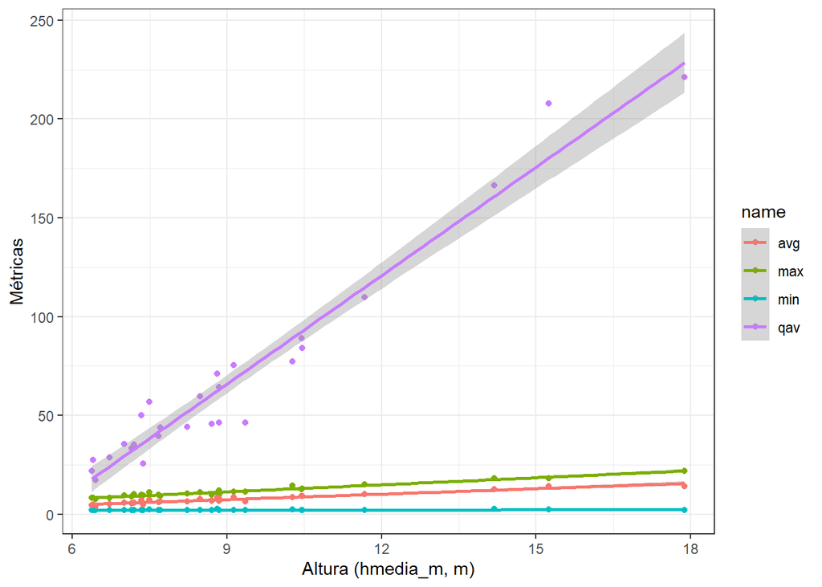

```r
# Ejemplo
hmedia_1 <-data %>% dplyr::select(13:16, hmedia_m)
hmedia_1 <- hmedia_1 %>%  pivot_longer(cols = -hmedia_m)
hmedia_1 <- hmedia_1 %>% filter(value > 0.5)

hmedia_1 %>% ggplot(aes(x = hmedia_m, y = value, color = name)) + geom_point()+
  stat_smooth(method="lm", formula=y ~ x) +theme_bw()+
  ylab("Métricas")+ xlab("Altura (hmedia_m, m)")
```

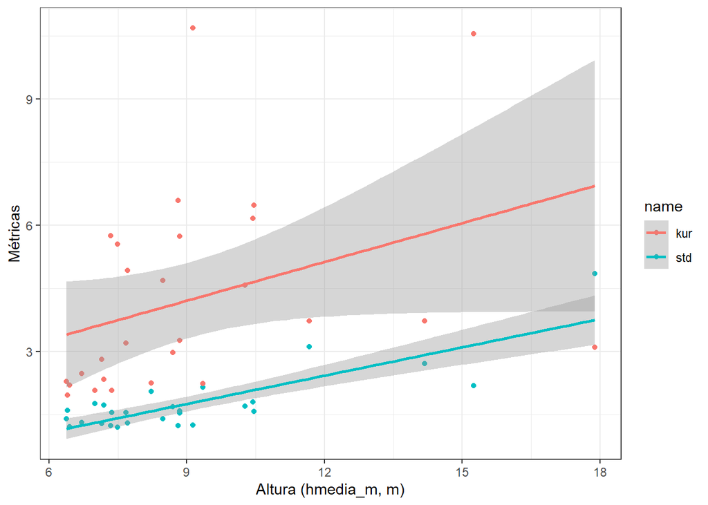

```r
hmedia_2 <-data %>% dplyr::select(17:19, hmedia_m)
hmedia_2 <- hmedia_2 %>%  pivot_longer(cols = -hmedia_m)
hmedia_2 <- hmedia_2 %>% filter(value > 0.5)

hmedia_2 %>% ggplot(aes(x = hmedia_m, y = value, color = name)) + geom_point()+
  stat_smooth(method="lm", formula=y ~ x) +theme_bw()+
  ylab("Métricas")+ xlab("Altura (hmedia_m, m)")
```

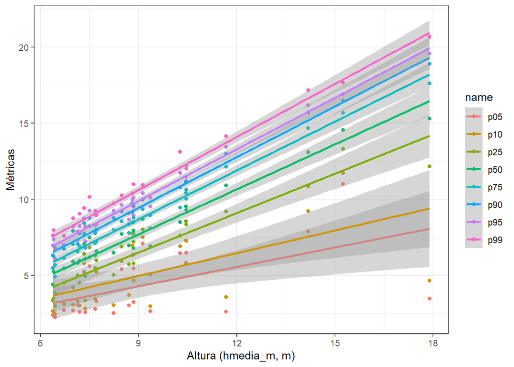

```r
hmedia_3 <-data %>% dplyr::select(20:27, hmedia_m)
hmedia_3 <- hmedia_3 %>%  pivot_longer(cols = -hmedia_m)
hmedia_3 <- hmedia_3 %>% filter(value > 0.5)

hmedia_3 %>% ggplot(aes(x = hmedia_m, y = value, color = name)) + geom_point()+
  stat_smooth(method="lm", formula=y ~ x) +theme_bw()+
  ylab("Métricas")+ xlab("Altura (hmedia_m, m)")
```

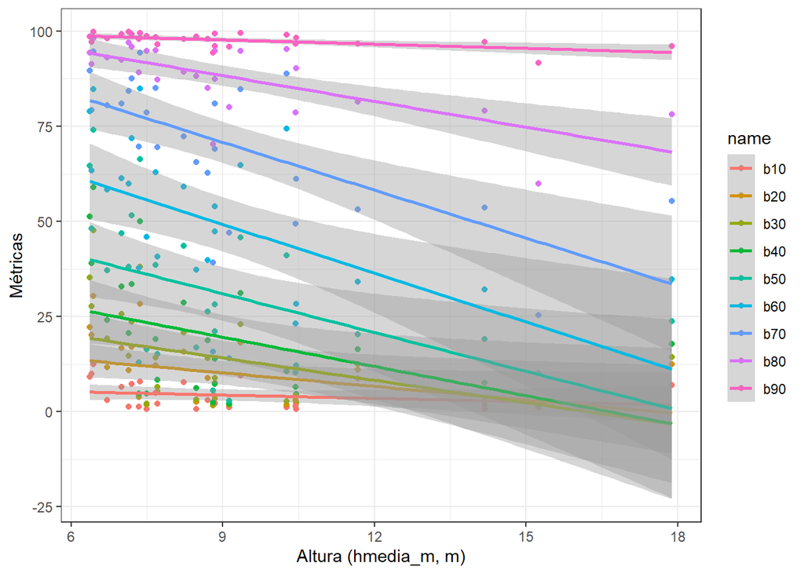

```r
hmedia_4 <-data %>% dplyr::select(28:36, hmedia_m)
hmedia_4 <- hmedia_4 %>%  pivot_longer(cols = -hmedia_m)
hmedia_4 <- hmedia_4 %>% filter(value > 0.5)

hmedia_4 %>% ggplot(aes(x = hmedia_m, y = value, color = name)) + geom_point()+
  stat_smooth(method="lm", formula=y ~ x) +theme_bw()+
  ylab("Métricas")+ xlab("Altura (hmedia_m, m)")
```

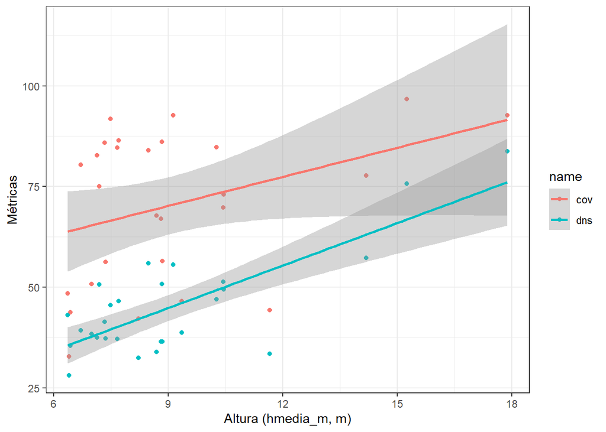

```r
hmedia_5 <-data %>% dplyr::select(37:38, hmedia_m)
hmedia_5 <- hmedia_5 %>%  pivot_longer(cols = -hmedia_m)
hmedia_5 <- hmedia_5 %>% filter(value > 0.5)

hmedia_5 %>% ggplot(aes(x = hmedia_m, y = value, color = name)) + geom_point()+
  stat_smooth(method="lm", formula=y ~ x) +theme_bw()+
  ylab("Métricas")+ xlab("Altura (hmedia_m, m)")
```

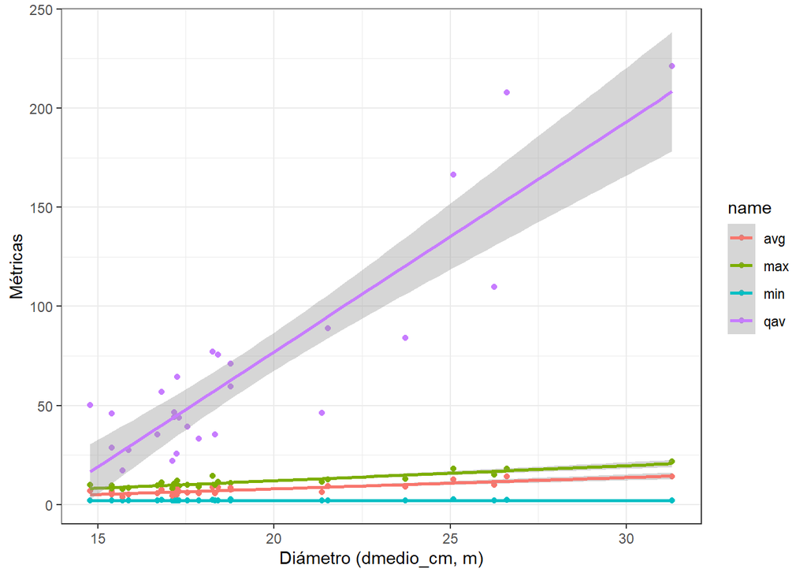

```r
# Ejemplo
dmedio_1 <-data %>% dplyr::select(13:16, dmedio_cm)
dmedio_1 <- dmedio_1 %>%  pivot_longer(cols = -dmedio_cm)
dmedio_1 <- dmedio_1 %>% filter(value > 0.5)

dmedio_1 %>% ggplot(aes(x = dmedio_cm, y = value, color = name)) + geom_point()+
  stat_smooth(method="lm", formula=y ~ x) +theme_bw()+
  ylab("Métricas")+ xlab("Diámetro (dmedio_cm, m)")
```

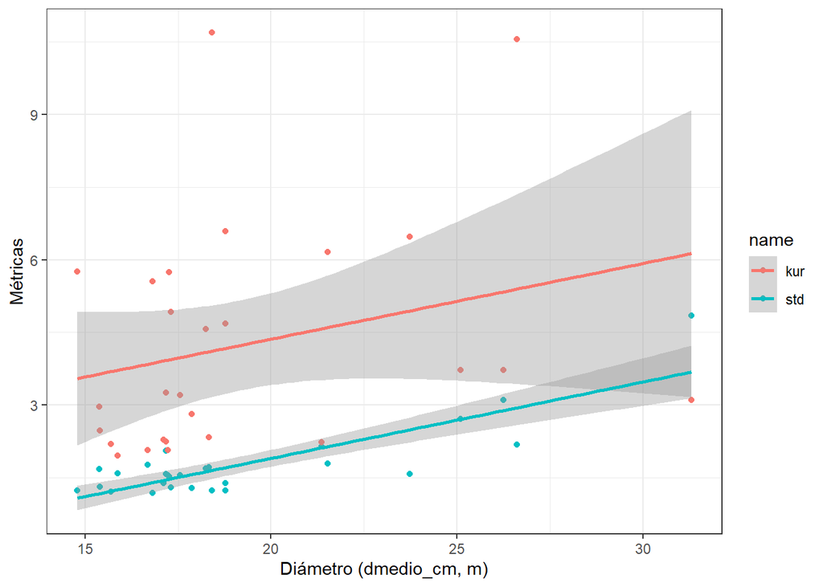

```r
dmedio_2 <-data %>% dplyr::select(17:19, dmedio_cm)
dmedio_2 <- dmedio_2 %>%  pivot_longer(cols = -dmedio_cm)
dmedio_2 <- dmedio_2 %>% filter(value > 0.5)

dmedio_2 %>% ggplot(aes(x = dmedio_cm, y = value, color = name)) + geom_point()+
  stat_smooth(method="lm", formula=y ~ x) +theme_bw()+
  ylab("Métricas")+ xlab("Diámetro (dmedio_cm, m)")
```

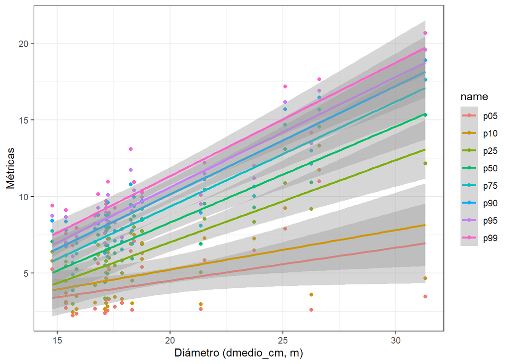

```r
dmedio_3 <-data %>% dplyr::select(20:27, dmedio_cm)
dmedio_3 <- dmedio_3 %>%  pivot_longer(cols = -dmedio_cm)
dmedio_3 <- dmedio_3 %>% filter(value > 0.5)

dmedio_3 %>% ggplot(aes(x = dmedio_cm, y = value, color = name)) + geom_point()+
  stat_smooth(method="lm", formula=y ~ x) +theme_bw()+
  ylab("Métricas")+ xlab("Diámetro (dmedio_cm, m)")
```

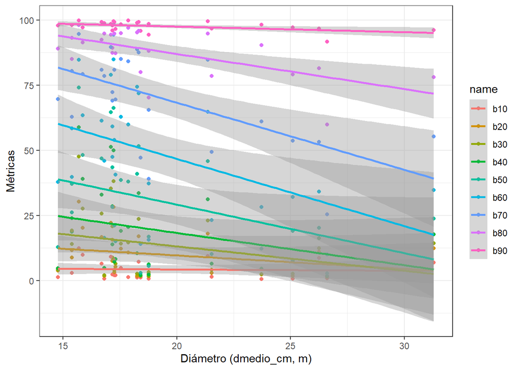

```r
dmedio_4 <-data %>% dplyr::select(28:36, dmedio_cm)
dmedio_4 <- dmedio_4 %>%  pivot_longer(cols = -dmedio_cm)
dmedio_4 <- dmedio_4 %>% filter(value > 0.5)

dmedio_4 %>% ggplot(aes(x = dmedio_cm, y = value, color = name)) + geom_point()+
  stat_smooth(method="lm", formula=y ~ x) +theme_bw()+
  ylab("Métricas")+ xlab("Diámetro (dmedio_cm, m)")
```

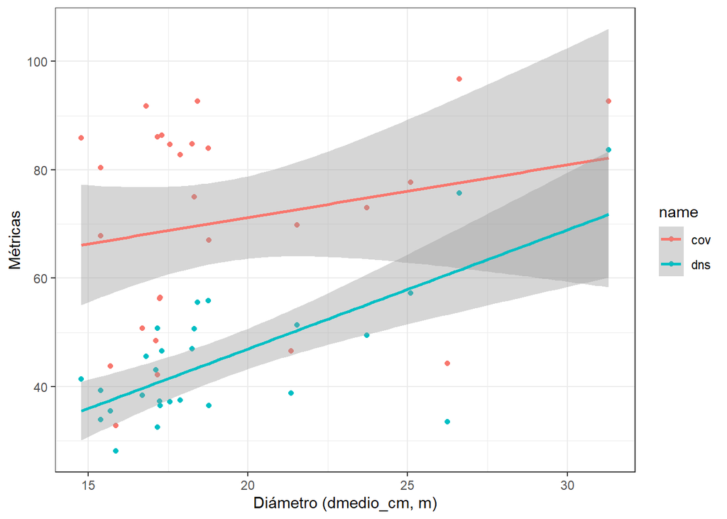

```r
dmedio_5 <-data %>% dplyr::select(37:38, dmedio_cm)
dmedio_5 <- dmedio_5 %>%  pivot_longer(cols = -dmedio_cm)
dmedio_5 <- dmedio_5 %>% filter(value > 0.5)

dmedio_5 %>% ggplot(aes(x = dmedio_cm, y = value, color = name)) + geom_point()+
  stat_smooth(method="lm", formula=y ~ x) +theme_bw()+
  ylab("Métricas")+ xlab("Diámetro (dmedio_cm, m)")
```

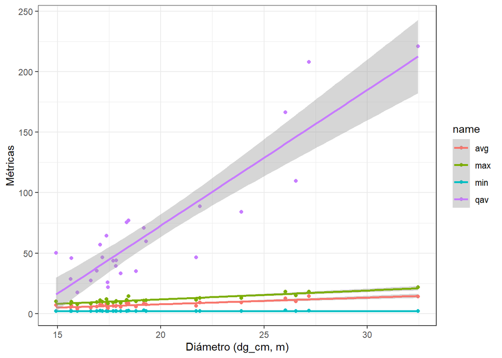

```r
# Ejemplo
dmedio_1 <-data %>% dplyr::select(13:16, dg_cm)
dmedio_1 <- dmedio_1 %>%  pivot_longer(cols = -dg_cm)
dmedio_1 <- dmedio_1 %>% filter(value > 0.5)

dmedio_1 %>% ggplot(aes(x = dg_cm, y = value, color = name)) + geom_point()+
  stat_smooth(method="lm", formula=y ~ x) +theme_bw()+
  ylab("Métricas")+ xlab("Diámetro (dg_cm, m)")
```

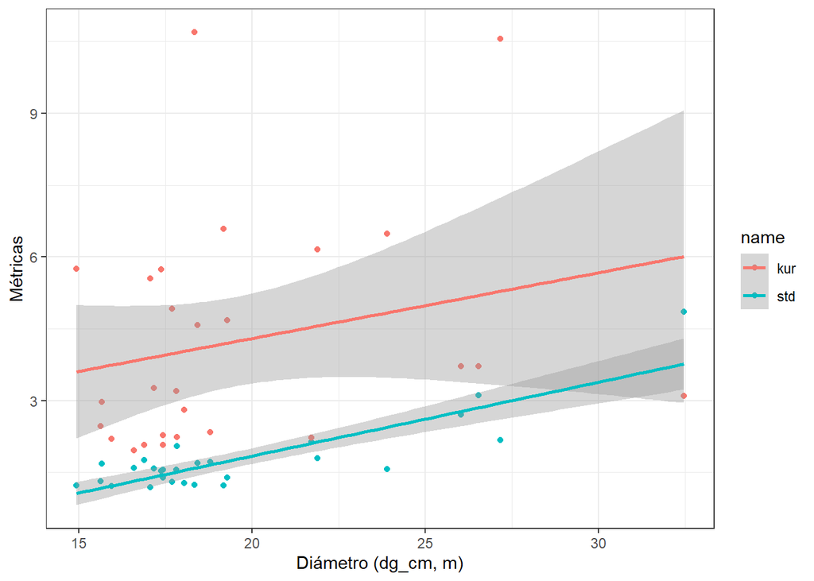

```r
dmedio_2 <-data %>% dplyr::select(17:19, dg_cm)
dmedio_2 <- dmedio_2 %>%  pivot_longer(cols = -dg_cm)
dmedio_2 <- dmedio_2 %>% filter(value > 0.5)

dmedio_2 %>% ggplot(aes(x = dg_cm, y = value, color = name)) + geom_point()+
  stat_smooth(method="lm", formula=y ~ x) +theme_bw()+
  ylab("Métricas")+ xlab("Diámetro (dg_cm, m)")
```

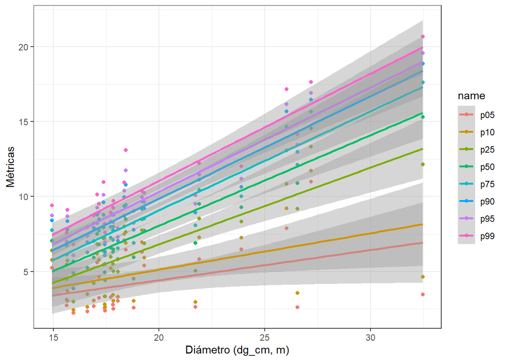

```r
dmedio_3 <-data %>% dplyr::select(20:27, dg_cm)
dmedio_3 <- dmedio_3 %>%  pivot_longer(cols = -dg_cm)
dmedio_3 <- dmedio_3 %>% filter(value > 0.5)

dmedio_3 %>% ggplot(aes(x = dg_cm, y = value, color = name)) + geom_point()+
  stat_smooth(method="lm", formula=y ~ x) +theme_bw()+
  ylab("Métricas")+ xlab("Diámetro (dg_cm, m)")
```

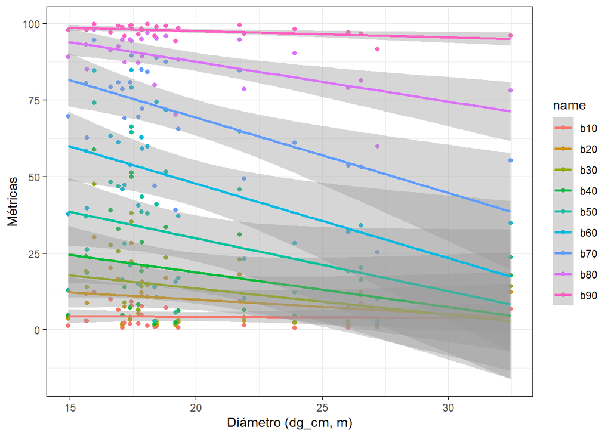

```r
dmedio_4 <-data %>% dplyr::select(28:36, dg_cm)
dmedio_4 <- dmedio_4 %>%  pivot_longer(cols = -dg_cm)
dmedio_4 <- dmedio_4 %>% filter(value > 0.5)

dmedio_4 %>% ggplot(aes(x = dg_cm, y = value, color = name)) + geom_point()+
  stat_smooth(method="lm", formula=y ~ x) +theme_bw()+
  ylab("Métricas")+ xlab("Diámetro (dg_cm, m)")
```

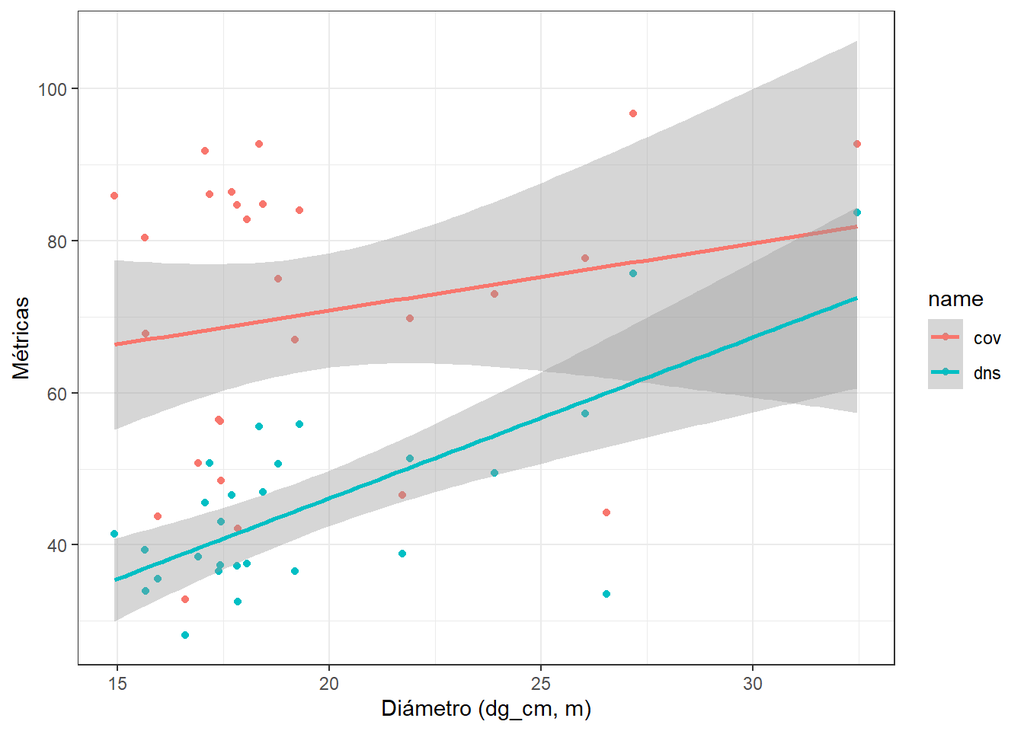

```r
dmedio_5 <-data %>% dplyr::select(37:38, dg_cm)
dmedio_5 <- dmedio_5 %>%  pivot_longer(cols = -dg_cm)
dmedio_5 <- dmedio_5 %>% filter(value > 0.5)

dmedio_5 %>% ggplot(aes(x = dg_cm, y = value, color = name)) + geom_point()+
  stat_smooth(method="lm", formula=y ~ x) +theme_bw()+
  ylab("Métricas")+ xlab("Diámetro (dg_cm, m)")
```

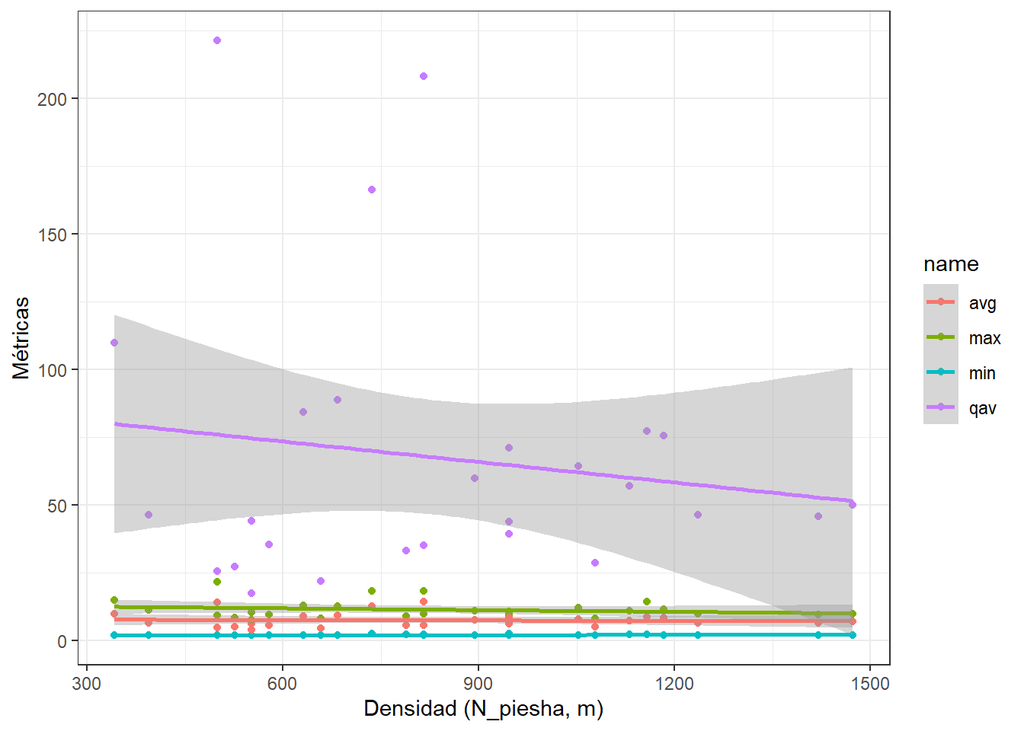

```r
# Ejemplo
Npies1 <-data %>% dplyr::select(13:16, N_piesha)
Npies1 <- Npies1 %>%  pivot_longer(cols = -N_piesha)
Npies1 <- Npies1 %>% filter(value > 0.5)

Npies1 %>% ggplot(aes(x = N_piesha, y = value, color = name)) + geom_point()+
  stat_smooth(method="lm", formula=y ~ x) +theme_bw()+
  ylab("Métricas")+ xlab("Densidad (N_piesha, m)")
```

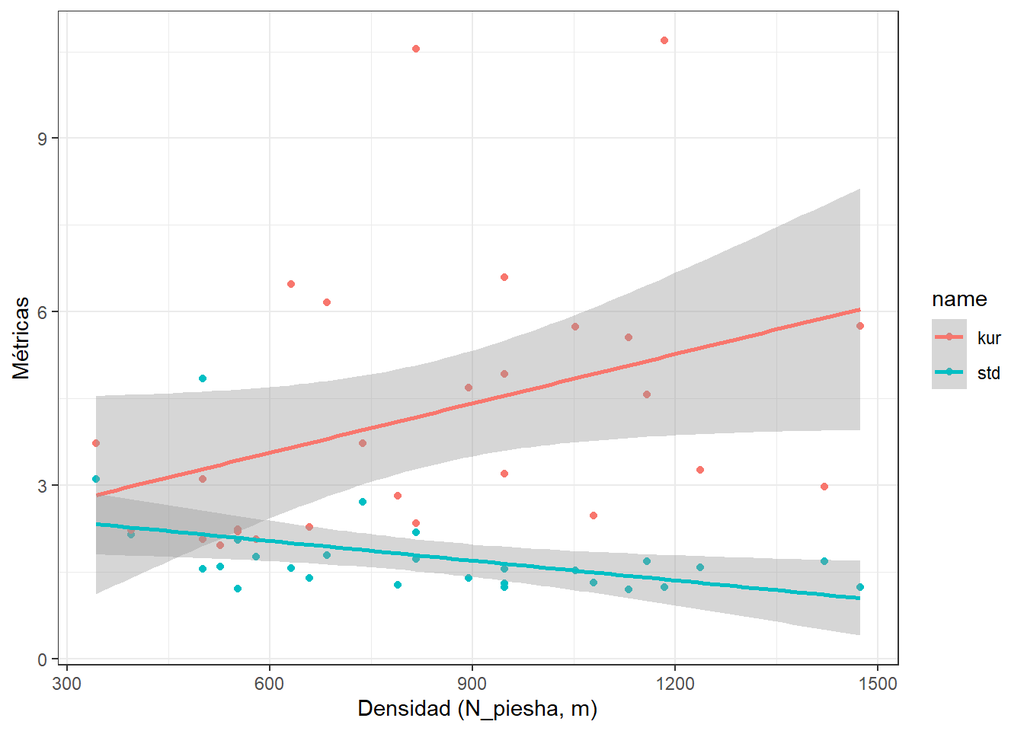

```r
Npies2 <-data %>% dplyr::select(17:19, N_piesha)
Npies2 <- Npies2 %>%  pivot_longer(cols = -N_piesha)
Npies2 <- Npies2 %>% filter(value > 0.5)

Npies2 %>% ggplot(aes(x = N_piesha, y = value, color = name)) + geom_point()+
  stat_smooth(method="lm", formula=y ~ x) +theme_bw()+
  ylab("Métricas")+ xlab("Densidad (N_piesha, m)")
```

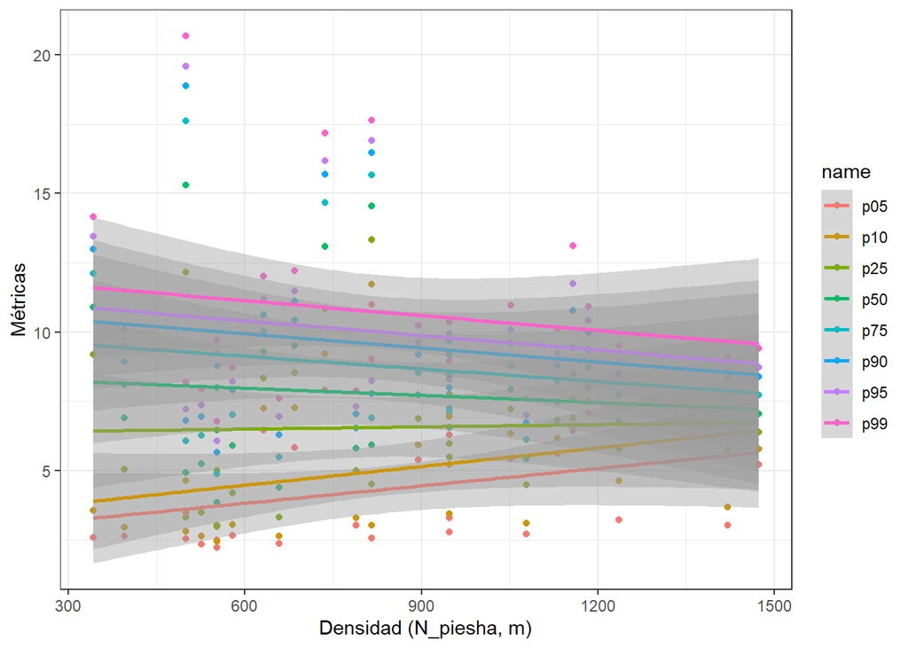

```r
Npies3 <-data %>% dplyr::select(20:27, N_piesha)
Npies3 <- Npies3 %>%  pivot_longer(cols = -N_piesha)
Npies3 <- Npies3 %>% filter(value > 0.5)

Npies3 %>% ggplot(aes(x = N_piesha, y = value, color = name)) + geom_point()+
  stat_smooth(method="lm", formula=y ~ x) +theme_bw()+
  ylab("Métricas")+ xlab("Densidad (N_piesha, m)")
```

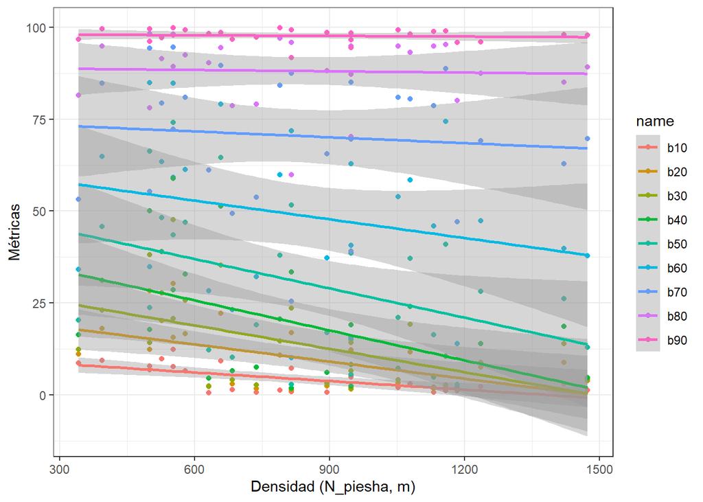

```r
Npies4 <-data %>% dplyr::select(28:36, N_piesha)
Npies4 <- Npies4 %>%  pivot_longer(cols = -N_piesha)
Npies4 <- Npies4 %>% filter(value > 0.5)

Npies4 %>% ggplot(aes(x = N_piesha, y = value, color = name)) + geom_point()+
  stat_smooth(method="lm", formula=y ~ x) +theme_bw()+
  ylab("Métricas")+ xlab("Densidad (N_piesha, m)")
```

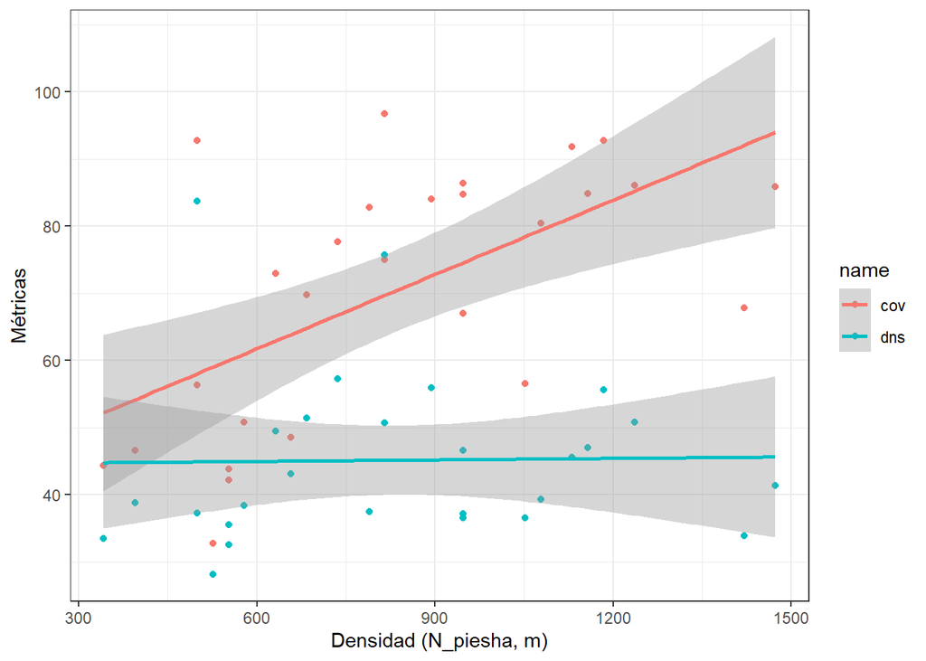

```r
Npies5 <-data %>% dplyr::select(37:38, N_piesha)
Npies5 <- Npies5 %>%  pivot_longer(cols = -N_piesha)
Npies5 <- Npies5 %>% filter(value > 0.5)

Npies5 %>% ggplot(aes(x = N_piesha, y = value, color = name)) + geom_point()+
  stat_smooth(method="lm", formula=y ~ x) +theme_bw()+
  ylab("Métricas")+ xlab("Densidad (N_piesha, m)")
```

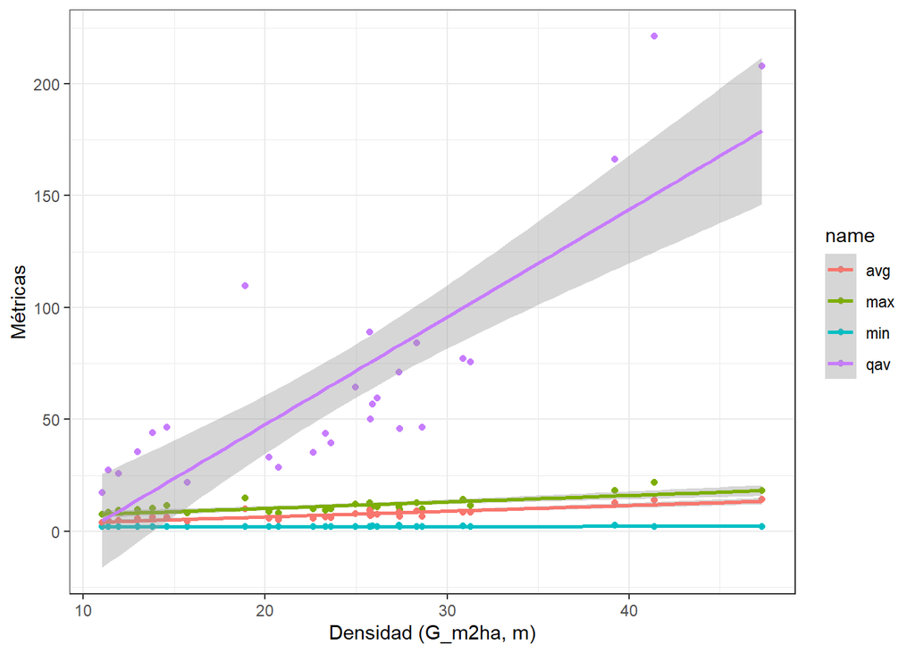

```r
# Ejemplo
AB1 <-data %>% dplyr::select(13:16, G_m2ha)
AB1 <- AB1 %>%  pivot_longer(cols = -G_m2ha)
AB1 <- AB1 %>% filter(value > 0.5)

AB1 %>% ggplot(aes(x = G_m2ha, y = value, color = name)) + geom_point()+
  stat_smooth(method="lm", formula=y ~ x) +theme_bw()+
  ylab("Métricas")+ xlab("Densidad (G_m2ha, m)")
```

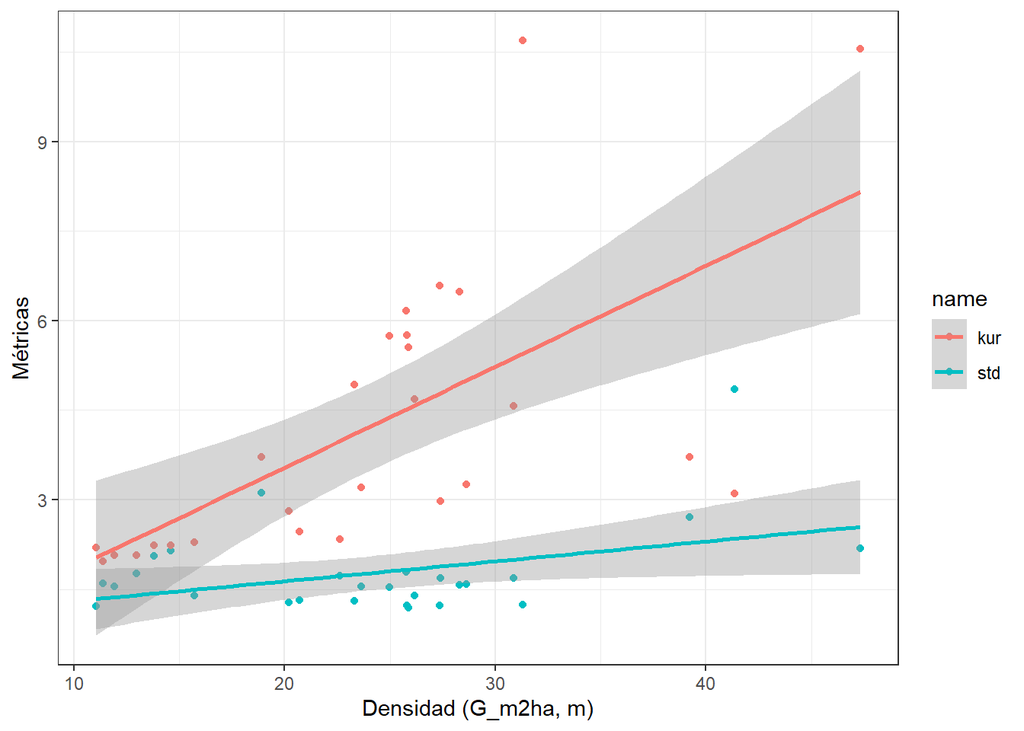

```r
AB2 <-data %>% dplyr::select(17:19, G_m2ha)
AB2 <- AB2 %>%  pivot_longer(cols = -G_m2ha)
AB2 <- AB2 %>% filter(value > 0.5)

AB2 %>% ggplot(aes(x = G_m2ha, y = value, color = name)) + geom_point()+
  stat_smooth(method="lm", formula=y ~ x) +theme_bw()+
  ylab("Métricas")+ xlab("Densidad (G_m2ha, m)")
```

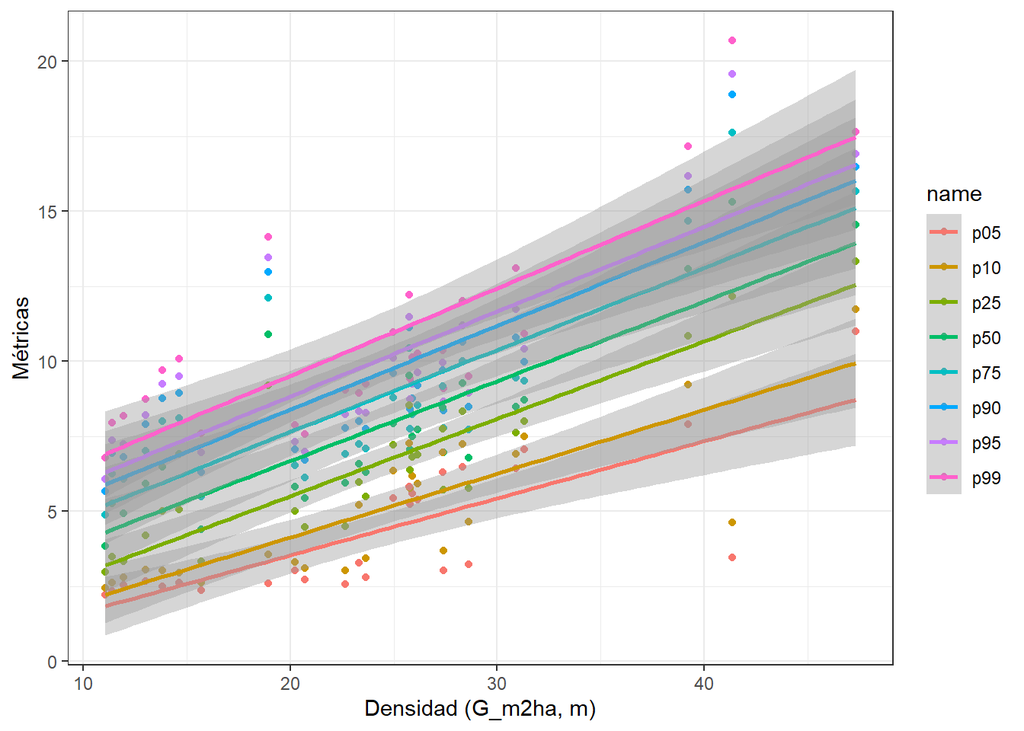

```r
AB3 <-data %>% dplyr::select(20:27, G_m2ha)
AB3 <- AB3 %>%  pivot_longer(cols = -G_m2ha)
AB3 <- AB3 %>% filter(value > 0.5)

AB3 %>% ggplot(aes(x = G_m2ha, y = value, color = name)) + geom_point()+
  stat_smooth(method="lm", formula=y ~ x) +theme_bw()+
  ylab("Métricas")+ xlab("Densidad (G_m2ha, m)")
```

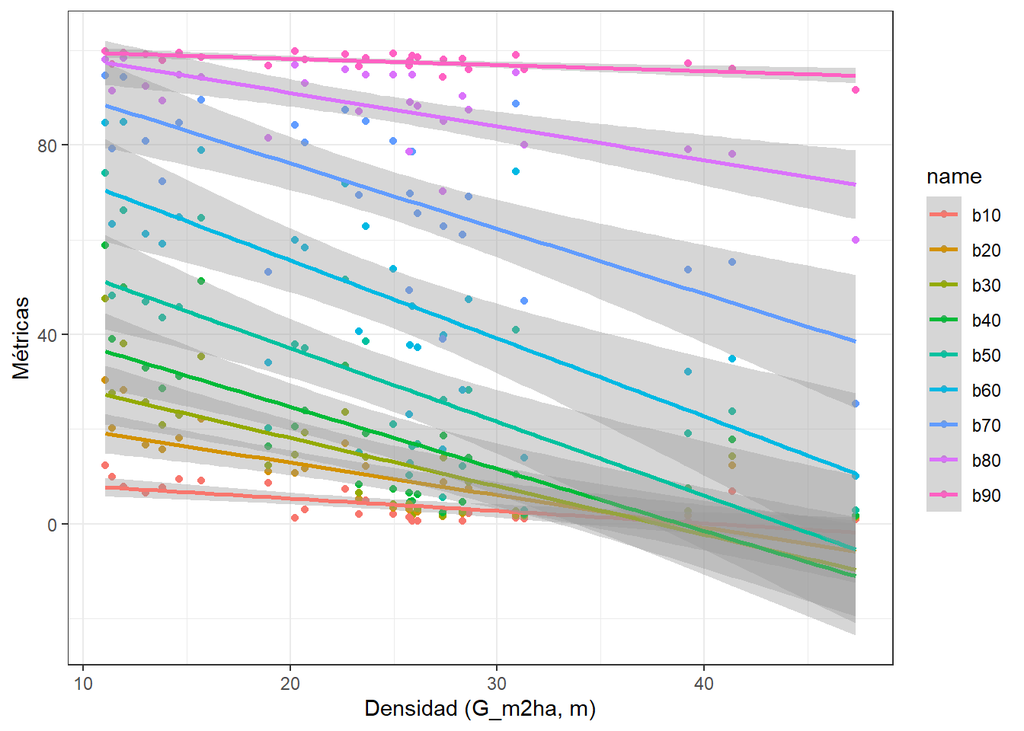

```r
AB4 <-data %>% dplyr::select(28:36, G_m2ha)
AB4 <- AB4 %>%  pivot_longer(cols = -G_m2ha)
AB4 <- AB4 %>% filter(value > 0.5)

AB4 %>% ggplot(aes(x = G_m2ha, y = value, color = name)) + geom_point()+
  stat_smooth(method="lm", formula=y ~ x) +theme_bw()+
  ylab("Métricas")+ xlab("Densidad (G_m2ha, m)")
```

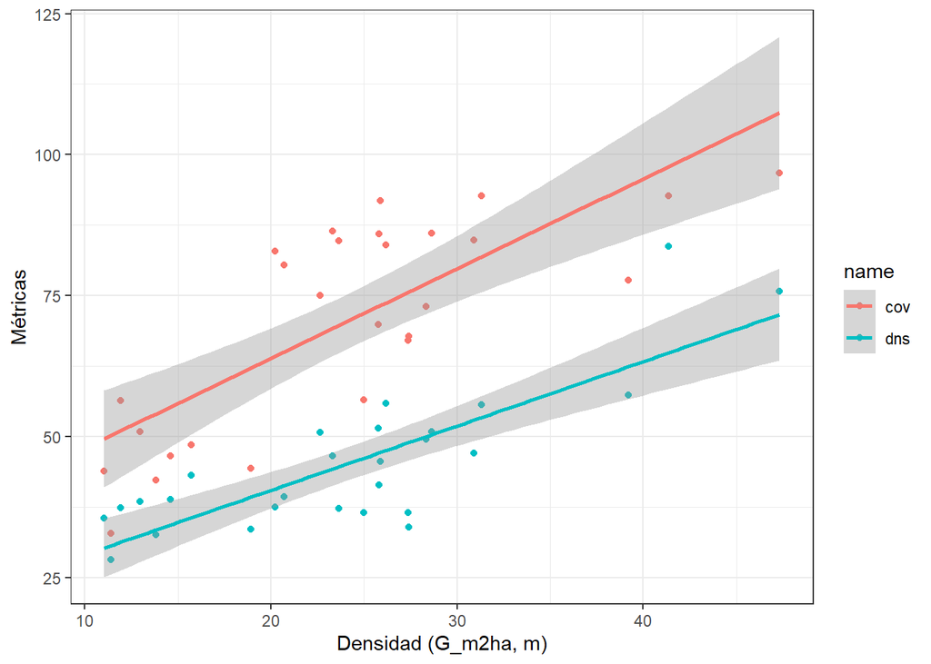

```r
AB5 <-data %>% dplyr::select(37:38, G_m2ha)
AB5 <- AB5 %>%  pivot_longer(cols = -G_m2ha)
AB5 <- AB5 %>% filter(value > 0.5)

AB5 %>% ggplot(aes(x = G_m2ha, y = value, color = name)) + geom_point()+
  stat_smooth(method="lm", formula=y ~ x) +theme_bw()+
  ylab("Métricas")+ xlab("Densidad (G_m2ha, m)")
```

En base a estos análisis gráficos, podemos deducir de forma preliminar:

- la altura media y la altura dominante se relacionan especialmente bien con los percentiles altos, el 90 y el 95 especialmente. La altura dominante se relciona mejor con el percentil 95 (pendiente cercana a 1:1), mientras que la media lo hace mejor con el percentil 90. También ambas se relacionan bien con la variable qav.
- el diametro medio cuadratico y el diametro medio aritmetico parecen tener cierta relación con bicentil 60, además de con la métrica qav y la desviación estándar (std).
- el número de pies por ha parece relacionarse levemente con la métrica de cobertura y la desviación estándar (std), aunque no muestra a simple vista ninguna relación clara o sólida con ninguna variable.
- el área basimétrica parece relacionarse medianamente bien con la kurtosis y con las métricas de densidad y cobertura.

Podemos también visualizar estas relaciones mediante la correlación de Pearson, en una matriz de correlación.

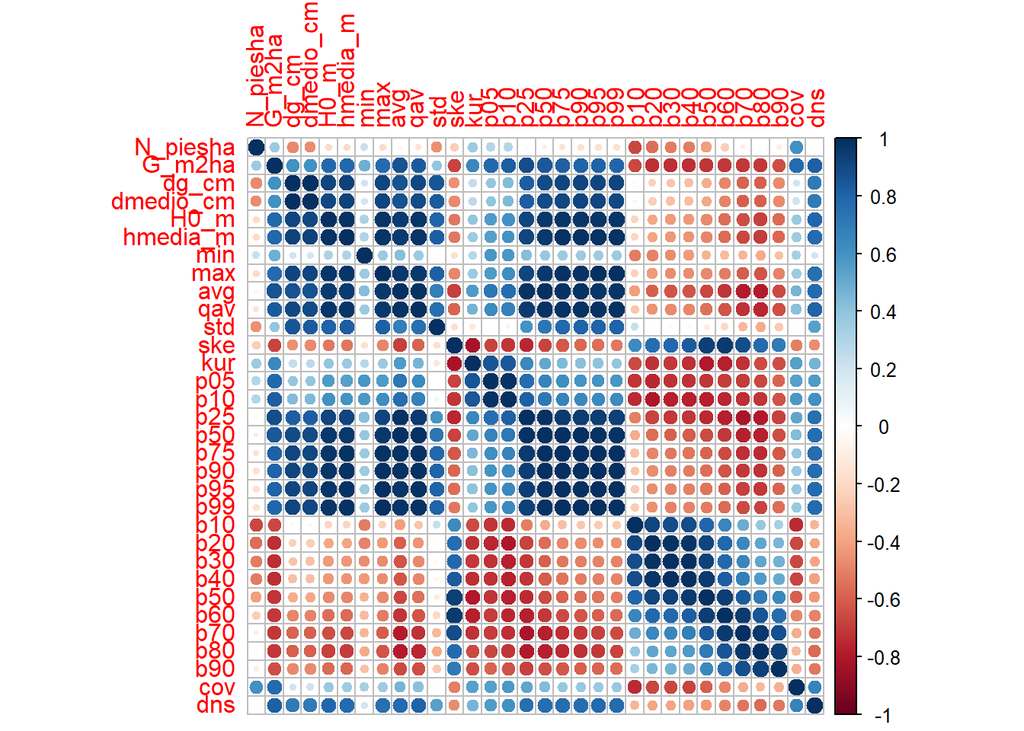

```r
library(corrplot)
cor <- cor(data[,-c(1:4,11:12)])
corrMatrix <- corrplot::corrplot(cor, method=c("circle"))
```

Esta matriz corrobora, de forma general, las observaciones realizadas.

## Análisis de multicolinearidad

Procedemos a evaluar ahora la multicolinearidad de los modelos que se van a implementar a continuación con las variables LiDAR que mejor explican las variables dasométricas explicadas anteriormente.

Antes de implementar los modelos, vamos a realizar una partición de los datos en 80%-20% para dividir así el dataset en entrenamiento (implementación de los modelos) y validación (para calcular el error al hacer una predicción).

```r
set.seed(7)
library(caret)
validation_index <- createDataPartition(data$H0, p=0.80, list=FALSE)
validacion <- data[-validation_index,]
training <- data[validation_index,]
```

```r
#Ajustamos el modelo de regresión
model_H0 <- lm(H0_m ~ p95 + qav, data= training)
model_Hmedia <- lm(hmedia_m ~ p90 + qav, data= training)
model_dmedio <- lm(dmedio_cm ~ std + qav + b60, data= training)
model_npies <- lm(N_piesha ~ cov + std, data= training)
model_AB <- lm(G_m2ha ~ cov + dns + kur, data= training)

# Visualicemos los resultados de los modelos
summary(model_H0)
```

```
##
## Call:
## lm(formula = H0_m ~ p95 + qav, data = training)
##
## Residuals:
##      Min       1Q   Median       3Q      Max
## -0.99352 -0.41039  0.07786  0.23248  1.25768
##
## Coefficients:
##             Estimate Std. Error t value Pr(>|t|)
## (Intercept)  4.16097    1.31470   3.165  0.00487 **
## p95          0.36299    0.22074   1.644  0.11572
## qav          0.03219    0.01350   2.384  0.02715 *
## ---
## Signif. codes:  0 '***' 0.001 '**' 0.01 '*' 0.05 '.' 0.1 ' ' 1
##
## Residual standard error: 0.5936 on 20 degrees of freedom
## Multiple R-squared:  0.9663, Adjusted R-squared:  0.9629
## F-statistic: 286.8 on 2 and 20 DF,  p-value: 1.883e-15
```

```r
summary(model_Hmedia)
```

```
##
## Call:
## lm(formula = hmedia_m ~ p90 + qav, data = training)
##
## Residuals:
##     Min      1Q  Median      3Q     Max
## -0.8548 -0.2740 -0.1107  0.2306  0.7824
##
## Coefficients:
##             Estimate Std. Error t value Pr(>|t|)
## (Intercept)  2.10535    1.08345   1.943  0.06620 .
## p90          0.60250    0.19430   3.101  0.00563 **
## qav          0.01687    0.01165   1.448  0.16316
## ---
## Signif. codes:  0 '***' 0.001 '**' 0.01 '*' 0.05 '.' 0.1 ' ' 1
##
## Residual standard error: 0.457 on 20 degrees of freedom
## Multiple R-squared:  0.9788, Adjusted R-squared:  0.9766
## F-statistic: 460.6 on 2 and 20 DF,  p-value: < 2.2e-16
```

```r
summary(model_dmedio)
```

```
##
## Call:
## lm(formula = dmedio_cm ~ std + qav + b60, data = training)
##
## Residuals:
##      Min       1Q   Median       3Q      Max
## -2.41064 -0.70204 -0.02077  0.75449  2.56196
##
## Coefficients:
##              Estimate Std. Error t value Pr(>|t|)
## (Intercept) 12.607893   1.136603  11.093 9.66e-10 ***
## std          2.096287   0.615848   3.404 0.002978 **
## qav          0.044409   0.011188   3.969 0.000822 ***
## b60         -0.009112   0.018797  -0.485 0.633376
## ---
## Signif. codes:  0 '***' 0.001 '**' 0.01 '*' 0.05 '.' 0.1 ' ' 1
##
## Residual standard error: 1.299 on 19 degrees of freedom
## Multiple R-squared:  0.9193, Adjusted R-squared:  0.9065
## F-statistic: 72.13 on 3 and 19 DF,  p-value: 1.438e-10
```

```r
summary(model_npies)
```

```
##
## Call:
## lm(formula = N_piesha ~ cov + std, data = training)
##
## Residuals:
##     Min      1Q  Median      3Q     Max
## -261.81 -140.15  -13.88   33.06  581.90
##
## Coefficients:
##             Estimate Std. Error t value Pr(>|t|)
## (Intercept)  530.657    196.871   2.695 0.013916 *
## cov            9.173      2.362   3.884 0.000922 ***
## std         -186.869     54.394  -3.435 0.002618 **
## ---
## Signif. codes:  0 '***' 0.001 '**' 0.01 '*' 0.05 '.' 0.1 ' ' 1
##
## Residual standard error: 210.1 on 20 degrees of freedom
## Multiple R-squared:  0.5646, Adjusted R-squared:  0.521
## F-statistic: 12.97 on 2 and 20 DF,  p-value: 0.000245
```

```r
summary(model_AB)
```

```
##
## Call:
## lm(formula = G_m2ha ~ cov + dns + kur, data = training)
##
## Residuals:
##     Min      1Q  Median      3Q     Max
## -5.7982 -3.3830 -0.3838  2.4687  9.9358
##
## Coefficients:
##             Estimate Std. Error t value Pr(>|t|)
## (Intercept) -5.33911    3.99898  -1.335  0.19761
## cov          0.12069    0.07508   1.608  0.12443
## dns          0.37868    0.09984   3.793  0.00123 **
## kur          0.95334    0.48024   1.985  0.06176 .
## ---
## Signif. codes:  0 '***' 0.001 '**' 0.01 '*' 0.05 '.' 0.1 ' ' 1
##
## Residual standard error: 4.628 on 19 degrees of freedom
## Multiple R-squared:  0.7924, Adjusted R-squared:  0.7597
## F-statistic: 24.18 on 3 and 19 DF,  p-value: 1.061e-06
```

```r
#Calcular FIV para cada predictor de los modelos con más de 1 variable
vif(model_H0)
```

```
##      p95      qav
## 35.59493 35.59493
```

```r
vif(model_Hmedia)
```

```
##      p90      qav
## 44.74037 44.74037
```

```r
vif(model_dmedio)
```

```
##      std      qav      b60
## 3.359906 5.105415 2.144045
```

```r
vif(model_npies)
```

```
##      cov      std
## 1.001387 1.001387
```

```r
vif(model_AB)
```

```
##      cov      dns      kur
## 2.085538 1.908451 1.437103
```

```r
#Ajustamos el modelo de regresión
model_H0 <- lm(H0_m ~ p95, data= training)
model_Hmedia <- lm(hmedia_m ~ p90, data= training)
model_dmedio <- lm(dmedio_cm ~ std + b60, data= training)
model_npies <- lm(N_piesha ~ cov + std, data= training)
model_AB <- lm(G_m2ha ~ cov + dns + kur, data= training)

# Visualicemos los resultados de los modelos
summary(model_H0)
```

```
##
## Call:
## lm(formula = H0_m ~ p95, data = training)
##
## Residuals:
##     Min      1Q  Median      3Q     Max
## -1.1916 -0.4646  0.1246  0.3271  1.3230
##
## Coefficients:
##             Estimate Std. Error t value Pr(>|t|)
## (Intercept)  1.17176    0.43709   2.681    0.014 *
## p95          0.88178    0.04092  21.551 8.38e-16 ***
## ---
## Signif. codes:  0 '***' 0.001 '**' 0.01 '*' 0.05 '.' 0.1 ' ' 1
##
## Residual standard error: 0.6564 on 21 degrees of freedom
## Multiple R-squared:  0.9567, Adjusted R-squared:  0.9547
## F-statistic: 464.4 on 1 and 21 DF,  p-value: 8.383e-16
```

```r
summary(model_Hmedia)
```

```
##
## Call:
## lm(formula = hmedia_m ~ p90, data = training)
##
## Residuals:
##      Min       1Q   Median       3Q      Max
## -0.82500 -0.27702 -0.08985  0.22507  0.85258
##
## Coefficients:
##             Estimate Std. Error t value Pr(>|t|)
## (Intercept)   0.5971     0.3053   1.955    0.064 .
## p90           0.8807     0.0298  29.555   <2e-16 ***
## ---
## Signif. codes:  0 '***' 0.001 '**' 0.01 '*' 0.05 '.' 0.1 ' ' 1
##
## Residual standard error: 0.4687 on 21 degrees of freedom
## Multiple R-squared:  0.9765, Adjusted R-squared:  0.9754
## F-statistic: 873.5 on 1 and 21 DF,  p-value: < 2.2e-16
```

```r
summary(model_dmedio)
```

```
##
## Call:
## lm(formula = dmedio_cm ~ std + b60, data = training)
##
## Residuals:
##     Min      1Q  Median      3Q     Max
## -3.7214 -1.1132  0.1108  1.1479  3.5874
##
## Coefficients:
##             Estimate Std. Error t value Pr(>|t|)
## (Intercept) 14.66861    1.33292  11.005 6.18e-10 ***
## std          4.12238    0.45425   9.075 1.58e-08 ***
## b60         -0.06236    0.01736  -3.593  0.00182 **
## ---
## Signif. codes:  0 '***' 0.001 '**' 0.01 '*' 0.05 '.' 0.1 ' ' 1
##
## Residual standard error: 1.712 on 20 degrees of freedom
## Multiple R-squared:  0.8523, Adjusted R-squared:  0.8376
## F-statistic: 57.72 on 2 and 20 DF,  p-value: 4.927e-09
```

```r
summary(model_npies)
```

```
##
## Call:
## lm(formula = N_piesha ~ cov + std, data = training)
##
## Residuals:
##     Min      1Q  Median      3Q     Max
## -261.81 -140.15  -13.88   33.06  581.90
##
## Coefficients:
##             Estimate Std. Error t value Pr(>|t|)
## (Intercept)  530.657    196.871   2.695 0.013916 *
## cov            9.173      2.362   3.884 0.000922 ***
## std         -186.869     54.394  -3.435 0.002618 **
## ---
## Signif. codes:  0 '***' 0.001 '**' 0.01 '*' 0.05 '.' 0.1 ' ' 1
##
## Residual standard error: 210.1 on 20 degrees of freedom
## Multiple R-squared:  0.5646, Adjusted R-squared:  0.521
## F-statistic: 12.97 on 2 and 20 DF,  p-value: 0.000245
```

```r
summary(model_AB)
```

```
##
## Call:
## lm(formula = G_m2ha ~ cov + dns + kur, data = training)
##
## Residuals:
##     Min      1Q  Median      3Q     Max
## -5.7982 -3.3830 -0.3838  2.4687  9.9358
##
## Coefficients:
##             Estimate Std. Error t value Pr(>|t|)
## (Intercept) -5.33911    3.99898  -1.335  0.19761
## cov          0.12069    0.07508   1.608  0.12443
## dns          0.37868    0.09984   3.793  0.00123 **
## kur          0.95334    0.48024   1.985  0.06176 .
## ---
## Signif. codes:  0 '***' 0.001 '**' 0.01 '*' 0.05 '.' 0.1 ' ' 1
##
## Residual standard error: 4.628 on 19 degrees of freedom
## Multiple R-squared:  0.7924, Adjusted R-squared:  0.7597
## F-statistic: 24.18 on 3 and 19 DF,  p-value: 1.061e-06
```

```r
#Calcular FIV para cada predictor de los modelos con más de 1 variable
vif(model_dmedio)
```

```
##      std      b60
## 1.051886 1.051886
```

```r
vif(model_npies)
```

```
##      cov      std
## 1.001387 1.001387
```

```r
vif(model_AB)
```

```
##      cov      dns      kur
## 2.085538 1.908451 1.437103
```

Vemos así que el VIF ha disminuido adecuadamente, mostrando valores máximos de 2 para todos los modelos multivariables. Para las alturas, a pesar de haber quedado una única variable, al ser muy buena la relación variable dasométrica-variable LiDAR, siguen obteniéndose estadísticos adecuados.

## Comprobación de la homocedasticidad (varianza constante de los residuos), independencia de los residuos (ausencia de autocorrelación) y de la normalidad de los mismos

### Homocedasticidad

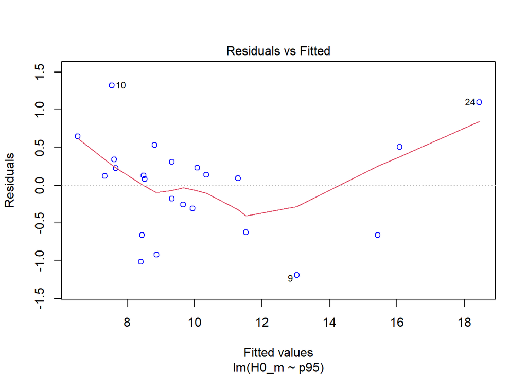

```r
plot(model_H0, which=1, col=c("blue"))
```

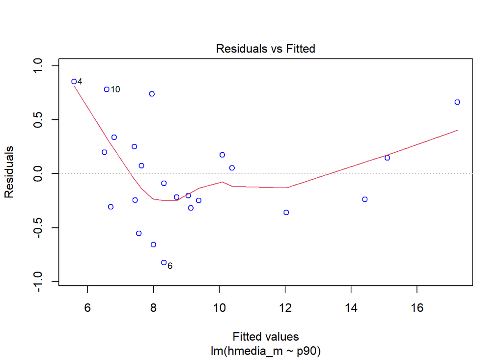

```r
plot(model_Hmedia, which=1, col=c("blue"))
```

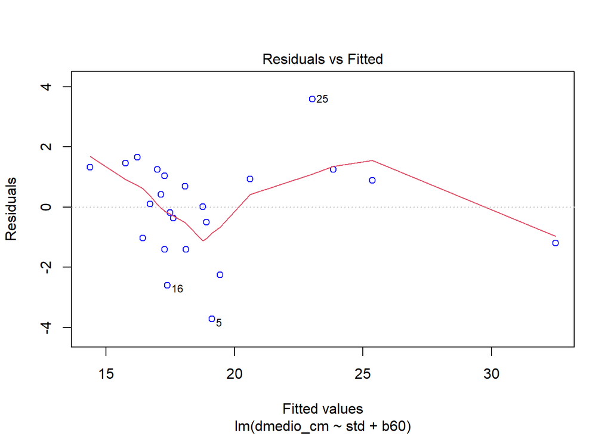

```r
plot(model_dmedio, which=1, col=c("blue"))
```

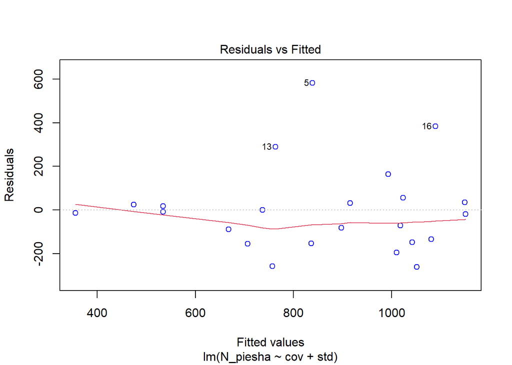

```r
plot(model_npies, which=1, col=c("blue"))
```

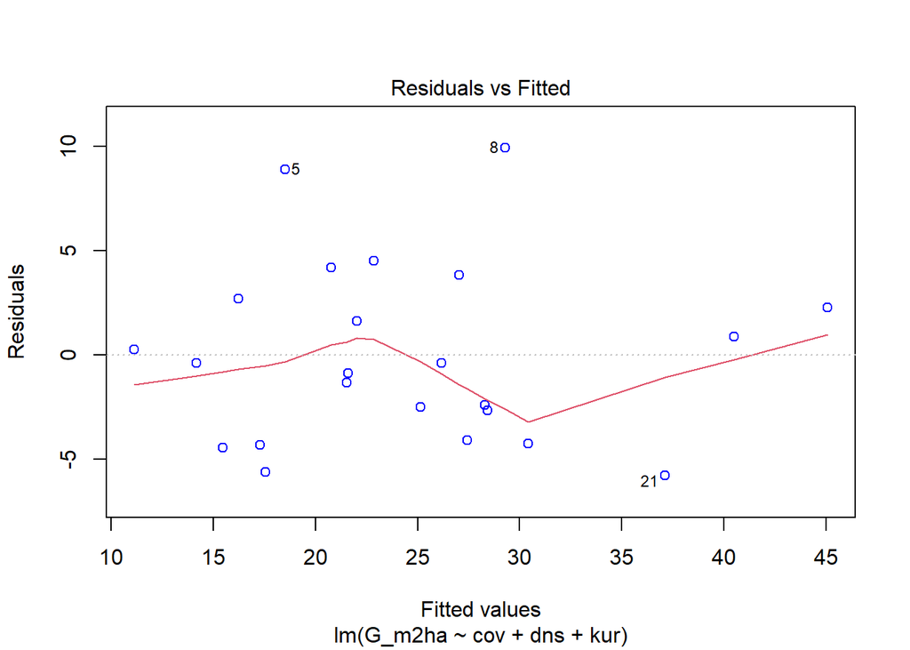

```r
plot(model_AB, which=1, col=c("blue"))
```

### Independencia

Para esto realizamos un test de Durbin-Watson con el paquete car.

```r
durbinWatsonTest(model_H0)
```

```
##  lag Autocorrelation D-W Statistic p-value
##    1      -0.1581064      2.299853    0.55
##  Alternative hypothesis: rho != 0
```

```r
durbinWatsonTest(model_Hmedia)
```

```
##  lag Autocorrelation D-W Statistic p-value
##    1      -0.1607534      2.295333    0.51
##  Alternative hypothesis: rho != 0
```

```r
durbinWatsonTest(model_dmedio)
```

```
##  lag Autocorrelation D-W Statistic p-value
##    1     -0.01318186      1.892574   0.748
##  Alternative hypothesis: rho != 0
```

```r
durbinWatsonTest(model_npies)
```

```
##  lag Autocorrelation D-W Statistic p-value
##    1      -0.1277411       2.17748   0.722
##  Alternative hypothesis: rho != 0
```

```r
durbinWatsonTest(model_AB)
```

```
##  lag Autocorrelation D-W Statistic p-value
##    1       0.1105496      1.774239   0.554
##  Alternative hypothesis: rho != 0
```

Este test parte de la hipótesis nula de que no existe correlación en los residuos. Dado que en todos los casos el p-valor es superior a 0.05, no podemos rechazar laa hipótesis nula, luego podemos concluir que a priori los residuos de todos los modelos implementados no están correlacionados entre sí.

### Normalidad

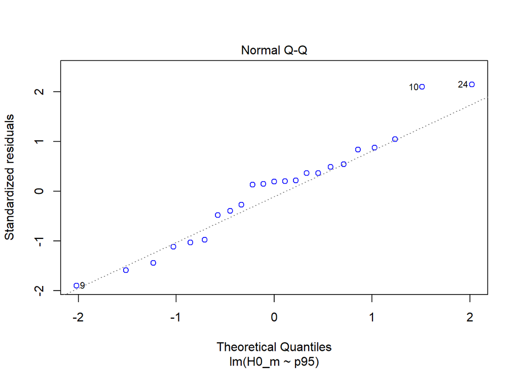

```r
plot(model_H0, which=2, col=c("blue"))
```

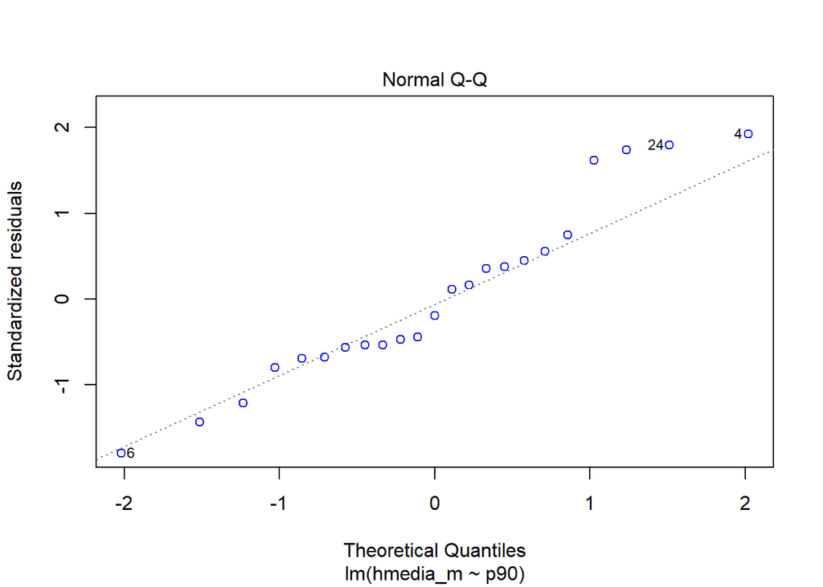

```r
plot(model_Hmedia, which=2, col=c("blue"))
```

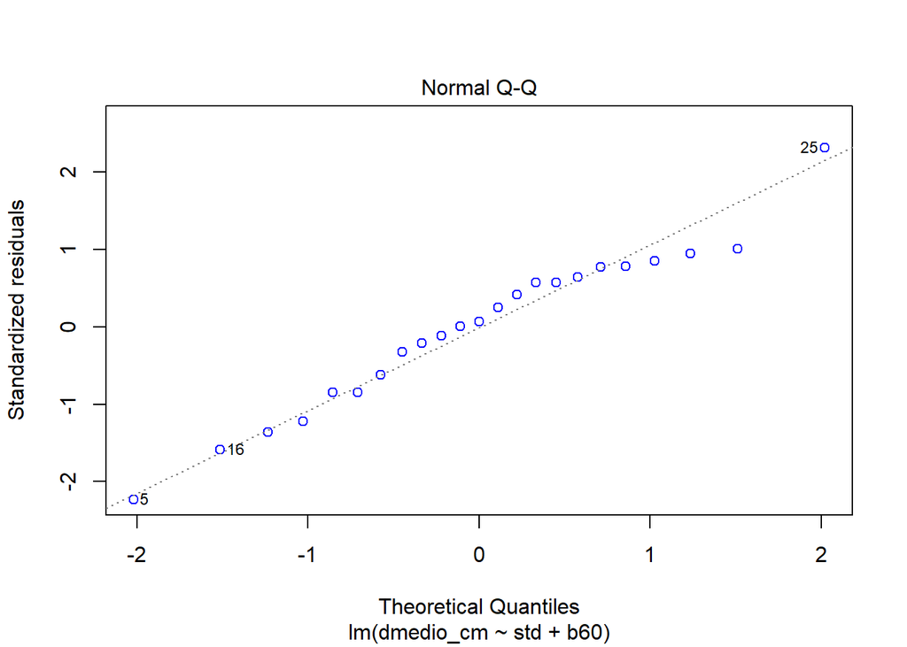

```r
plot(model_dmedio, which=2, col=c("blue"))
```

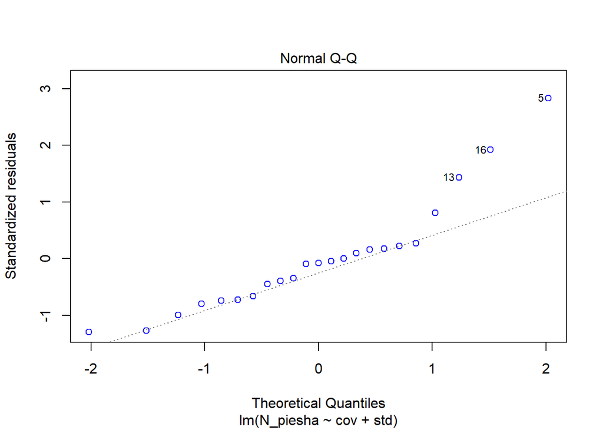

```r
plot(model_npies, which=2, col=c("blue"))
```

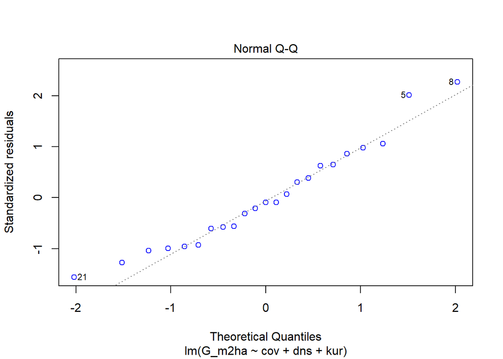

```r
plot(model_AB, which=2, col=c("blue"))
```

## PLS

Vamos a probar con un modelo PLS, que permite lidiar con datasets de muchas variables y pocas observaciones, como es nuestro caso.

```r
#install.packages("pls")
#load pls package
library(pls)
library(caret)
#fit PLS model
training <- na.omit(training)
model_H0PLS <- plsr(H0_m ~ min + max + avg + qav + std + ske + kur + p05 + p10 + p25 + p50 + p75 + p90 + p95 + p99 + b10 + b20 + b30 + b40 + b50 + b60 + b70 + b80 + b90 + cov + dns, data=training, scale=TRUE, validation="CV")
#view summary of model fitting
summary(model_H0PLS)
```

```
## Data:    X dimension: 23 26
##  Y dimension: 23 1
## Fit method: kernelpls
## Number of components considered: 19
##
## VALIDATION: RMSEP
## Cross-validated using 10 random segments.
##        (Intercept)  1 comps  2 comps  3 comps  4 comps  5 comps  6 comps
## CV           3.153    1.472   0.6585   0.7164   0.8932   1.0041    1.067
## adjCV        3.153    1.460   0.6498   0.7038   0.8660   0.9605    1.025
##        7 comps  8 comps  9 comps  10 comps  11 comps  12 comps  13 comps
## CV       1.092    1.145    1.293     1.621     1.971     2.433     2.801
## adjCV    1.046    1.096    1.235     1.539     1.870     2.307     2.655
##        14 comps  15 comps  16 comps  17 comps  18 comps  19 comps
## CV        3.000     3.110     3.183     3.314     3.270     3.319
## adjCV     2.844     2.945     3.011     3.131     3.089     3.135
##
## TRAINING: % variance explained
##       1 comps  2 comps  3 comps  4 comps  5 comps  6 comps  7 comps  8 comps
## X       63.95    82.63    88.76    92.33    93.31    95.76    98.38    98.80
## H0_m    83.71    96.68    97.07    97.23    97.76    97.92    98.01    98.25
##       9 comps  10 comps  11 comps  12 comps  13 comps  14 comps  15 comps
## X       99.16     99.35     99.74     99.79     99.88     99.92     99.94
## H0_m    98.33     98.47     98.53     98.71     98.78     98.94     99.30
##       16 comps  17 comps  18 comps  19 comps
## X        99.97     99.98     99.99     100.0
## H0_m     99.40     99.59     99.67      99.8
```

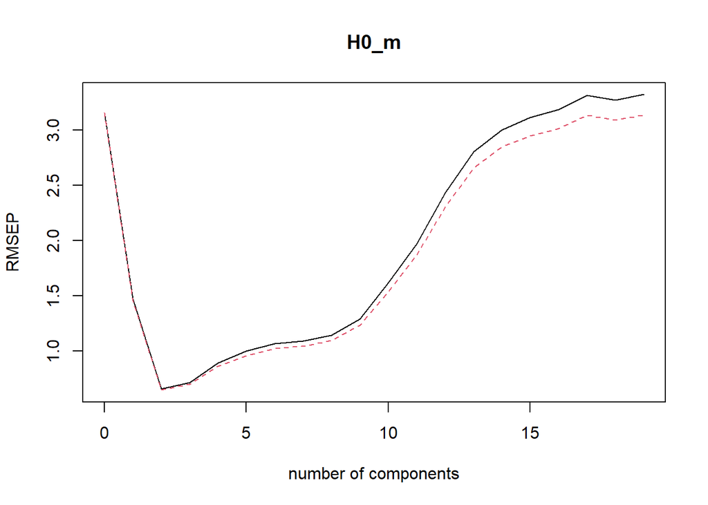

```r
#visualize cross-validation plots
validationplot(model_H0PLS)
```

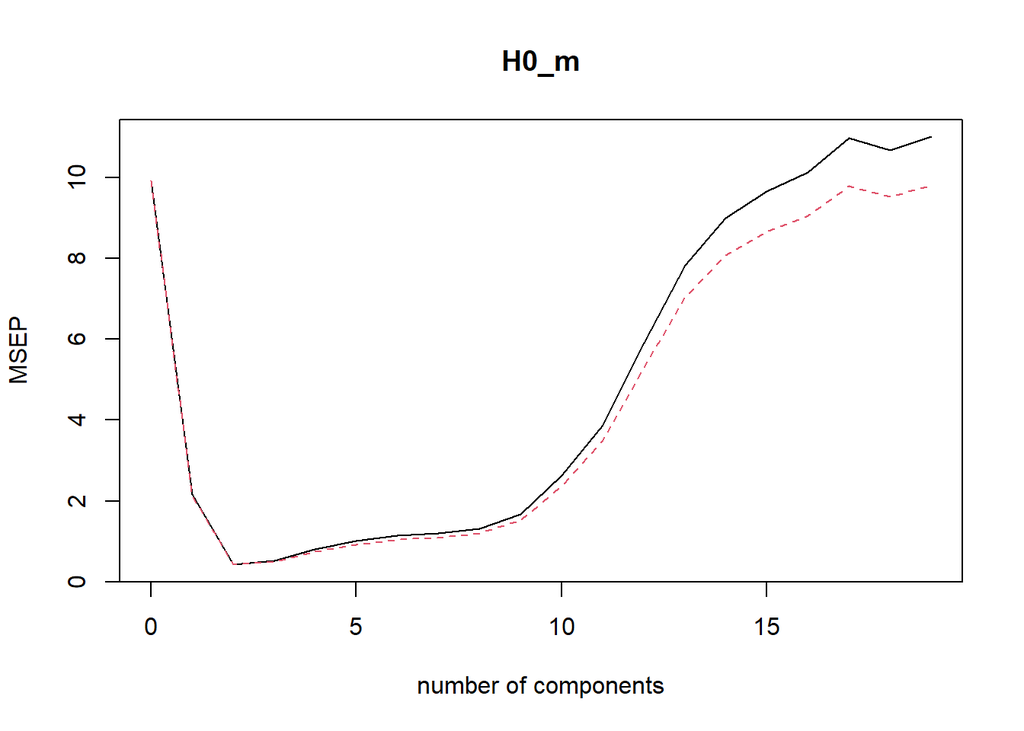

```r
validationplot(model_H0PLS, val.type="MSEP")
```

```r
#obtenemos los valores concretos de R2
pls::R2(model_H0PLS)
```

```
## (Intercept)      1 comps      2 comps      3 comps      4 comps      5 comps
##    -0.09298      0.76177      0.95232      0.94356      0.91228      0.88913
##     6 comps      7 comps      8 comps      9 comps     10 comps     11 comps
##     0.87478      0.86880      0.85586      0.81605      0.71118      0.57302
##    12 comps     13 comps     14 comps     15 comps     16 comps     17 comps
##     0.34922      0.13728      0.01042     -0.06366     -0.11408     -0.20727
##    18 comps     19 comps
##    -0.17603     -0.21152
```

## Cálculo de errores para los modelos elegidos

En esta última etapa comparamos los datos obtenidos en campo con los predichos por el modelo, empleando para ello el 20% reservado para validación cuado se hizo la partición del dataset.

```r
PredictModLineal_H0 <- predict(model_H0, data=validacion)
PredictModLineal_hmedia <- predict(model_Hmedia, data=validacion)
PredictModLineal_dmedio <- predict(model_dmedio, data=validacion)
PredictModLineal_npies <- predict(model_npies, data=validacion)
PredictModLineal_AB <- predict(model_AB, data=validacion)

RMSE_lineal_H0 <- rmse(validacion$H0_m, PredictModLineal_H0)
RMSE_lineal_hmedia <- rmse(validacion$hmedia_m, PredictModLineal_hmedia)
RMSE_lineal_dmedio <- rmse(validacion$dmedio_cm, PredictModLineal_dmedio)
RMSE_lineal_npies <- rmse(validacion$N_piesha, PredictModLineal_npies)
RMSE_lineal_AB <- rmse(validacion$hmedia_m, PredictModLineal_AB)

RMSE_lineal_H0
```

```
## [1] 3.127476
```

```r
RMSE_lineal_hmedia
```

```
## [1] 3.018167
```

```r
RMSE_lineal_dmedio
```

```
## [1] 3.827703
```

```r
RMSE_lineal_npies
```

```
## [1] 346.2517
```

```r
RMSE_lineal_AB
```

```
## [1] 17.85716
```